# Modelling the Measles Outbreak of 1861 in Hagelloch

2026-04-07

# Introduction

Data were collected from a Measles outbreak in an isolated German village, Hagelloch, in 1861. Available in the surveillance R package. Data on the 188 cases in the measles outbreak among children were originally collected by Dr. Albert Pfeilsticker at the time of the outbreak and published in a paper in 1863. The dataset was augmented and re-analysed by Dr. Heike Oesterle (1992).

# Step 1 - Datasets : Exploratory Data Analysis

### Get Hagelloch dataset

```r
# load the data from surveillance package
data("hagelloch")
df_measles_orig <- hagelloch.df
remove(hagelloch.df, hagelloch)

# get a subset of variables
df_measles <- df_measles_orig %>%
    select(PN, IFTO, AGE, PRO, tPRO, ERU, tR, GE, CL, x.loc, y.loc) %>%
    mutate(days_infected = round(tR - tPRO)) %>%
    identity()

# Calculate SI - get symptom start for infecting person
df_infectingperson <- df_measles %>% select(IFTO = PN, tINFECTING_PRO = tPRO)

# join onto the main data
df_measles <- df_measles %>%
    left_join(df_infectingperson, by = 'IFTO') %>%
    mutate(SI = tPRO - tINFECTING_PRO) %>%
    identity()
```

Basic EDA checks suggest some data cleaning should be considered. Looking at a histogram of the day first symptoms appeared (prodromes), there’s a single case which presented significantly later than the penultimte cases preceeding it. We’ll drop this case (PN = 141) from the dataset.

NOTE : *I’ve used the new dplyr filter_out function to drop this record, you’ll need to be sure to use the latest version of the dplyr library.*

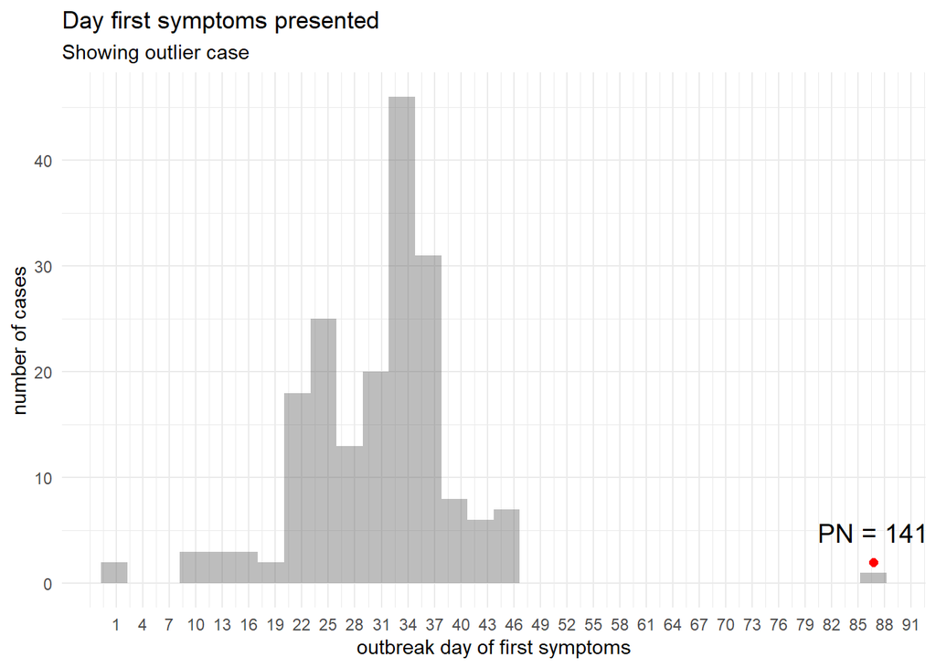

```r
df_measles %>%
    ggplot(aes(tPRO)) +
    geom_histogram(bins = 30, alpha = 0.4) +
    theme_minimal() +
    scale_x_continuous(breaks =  seq(1, nrow(df_measles), 3)) +
    labs(title = 'Day first symptoms presented',
         subtitle = 'Showing outlier case',
         x = 'outbreak day of first symptoms',
         y = 'number of cases') +
    geom_point(
        data = df_measles %>% filter(tPRO > 50),
        aes(x = tPRO, y = 2),
        colour = "red",
        size = 2
    ) +
    geom_text(
        data = df_measles %>% filter(tPRO > 50),
        aes(x = tPRO, y = 3, label = glue::glue('PN = {PN}')),
        vjust = -0.5,
        size = 5
    )
```

```r
# you'll need the very latest version of dplyr to use filter_out.
df_measles <- df_measles %>% filter_out(PN == 141)
```

### Get England and Wales Measles dataset

```r
# Measles Notifications and Deaths 1940-2025
df_uk_orig <- read_csv('measles-uk.csv')
# Population data from ONS
df_pop <- tibble(Year = c(1940, 1941, 1951, 1961, 1971, 1981, 1991, 2001, 2011, 2021, 2023),
                 Population = c(41.75, 41.75, 43.82, 46.20, 49.15, 49.63, 51.10, 52.21, 56.08, 59.60, 61.10))

# calculate a rolling average, and population percentages
df_uk <- df_uk_orig %>%
    mutate(rolling4 = (lag(Notifications, n=1) +
               lag(Notifications, n=2) +
               lag(Notifications, n=3) +
               lag(Notifications, n=4)) / 4) %>%
    left_join(df_pop, by='Year') %>%
    fill(Population) %>%
    mutate(under15_calc = Population * 1000000 * .18) %>%
    mutate(measles_prop = Notifications / under15_calc * 100) %>%
    mutate(deceased_pcent = `Total deaths` / Notifications * 100) %>%
    identity()
```

```r
tibble(
    Variable = names(df_measles),
    datatype = map_chr(df_measles, ~ paste(class(.x), collapse = ", ")),
    count_unique = map_int(df_measles, ~ n_distinct(.x, na.rm = TRUE)),
    count_na = map_int(df_measles, ~ sum(is.na(.x)))
    ) %>%
    left_join(fn_load_descriptions(), by = 'Variable') %>%
    mutate(order = row_number()) %>%
    select(Variable, description, order, everything()) %>%
    gt() %>%
    opt_vertical_padding(scale = 0) %>%
    tab_header(title = 'Schema for Hagelloch dataset',
               subtitle = 'Infected Individuals') %>%
    identity()
```

Schema for Hagelloch dataset

Infected Individuals

| Variable | description | order | datatype | count_unique | count_na |
| --- | --- | --- | --- | --- | --- |
| PN | patient number | 1 | integer | 187 | 0 |
| IFTO | patient no infection source | 2 | integer | 62 | 3 |
| AGE | age in years | 3 | numeric | 20 | 0 |
| PRO | Date of prodromes | 4 | Date | 35 | 0 |
| tPRO | first symptoms days post (30 Oct 1861) | 5 | numeric | 187 | 0 |
| ERU | Date of rash | 6 | Date | 34 | 0 |
| tR | Day infectious ends | 7 | numeric | 187 | 0 |
| GE | generation number of case | 8 | integer | 2 | 0 |
| CL | school class | 9 | factor | 3 | 0 |
| x.loc | x coord (in meters) | 10 | numeric | 41 | 0 |
| y.loc | y coord (in meters) | 11 | numeric | 44 | 0 |
| days_infected | Number of days infected (calculated) | 12 | numeric | 12 | 0 |
| tINFECTING_PRO | Prodromes of infecting patient (calculated) | 13 | numeric | 62 | 3 |
| SI | Serial Interval (calculated) | 14 | numeric | 184 | 3 |

```r
tibble(
    Variable = names(df_uk),
    datatype = map_chr(df_uk, ~ paste(class(.x), collapse = ", ")),
    count_unique = map_int(df_uk, ~ n_distinct(.x, na.rm = TRUE)),
    count_na = map_int(df_uk, ~ sum(is.na(.x)))
    ) %>%
    mutate(order = row_number()) %>%
    select(Variable, order, everything()) %>%
    gt() %>%
    opt_vertical_padding(scale = 0) %>%
    tab_header(title = 'Schema for England and Wales Measles dataset',
               subtitle = '1940 - 2025') %>%
    identity()
```

Schema for England and Wales Measles dataset

1940 - 2025

| Variable | order | datatype | count_unique | count_na |
| --- | --- | --- | --- | --- |
| Year | 1 | numeric | 86 | 0 |
| Notifications | 2 | numeric | 86 | 0 |
| Total deaths | 3 | numeric | 50 | 0 |
| Description | 4 | character | 14 | 69 |
| rolling4 | 5 | numeric | 82 | 4 |
| Population | 6 | numeric | 10 | 0 |
| under15_calc | 7 | numeric | 10 | 0 |
| measles_prop | 8 | numeric | 86 | 0 |
| deceased_pcent | 9 | numeric | 80 | 0 |

# Step 2 - Create day based dataset

Create a tibble where each record is the day of the outbreak, so later we can calculate totals for the SEIR compartments on each day. Although the exposure date for each individual is unknown, from our existing knowledge of measles assume this is average 10 days before first symptoms appear.

```r
# first symptom date
date_start <-  min(df_measles$PRO)
# final rash start date
date_final <- max(df_measles$ERU)

# assume exposure (average) 10 day before symptoms
# allow 5 days after last rash appears for charts to fade out
days_fade_in <- 11
days_fade_out <- 5
df_dates <-
        # days before the first symptoms, so Exposed compartment is in this time period
        tibble(date = seq(as.Date(date_start - days_fade_in), as.Date(date_start - 1), by='day')) %>%
        # days from first symptoms to final rash appearing, so Infectious compartment is in this period
        bind_rows(tibble(date = seq(as.Date(date_start), as.Date(date_final), by='day'))) %>%
        # days after last rash appears, so all Infections will move into Recovered compartment during this time
        bind_rows(tibble(date = seq(as.Date(date_final + 1), as.Date(date_final + days_fade_out), by='day'))) %>%
        # make a day number where first symptoms are on day 1
        mutate(day = row_number() - days_fade_in)

message(paste0('... first symptom ',date_start,' (day 1), final rash started ', date_final))
```

```
## ... first symptom 1861-10-30 (day 1), final rash started 1861-12-19
```

# Step 3 - Create SEIR data from the dataset

The dataset records the day the first symptoms appreared and the day of recovery for each individual. We are assuming measles takes 10 days from exposure to first symptoms - and therefore we can calculate the SEIR figures for each day of the outbreak.

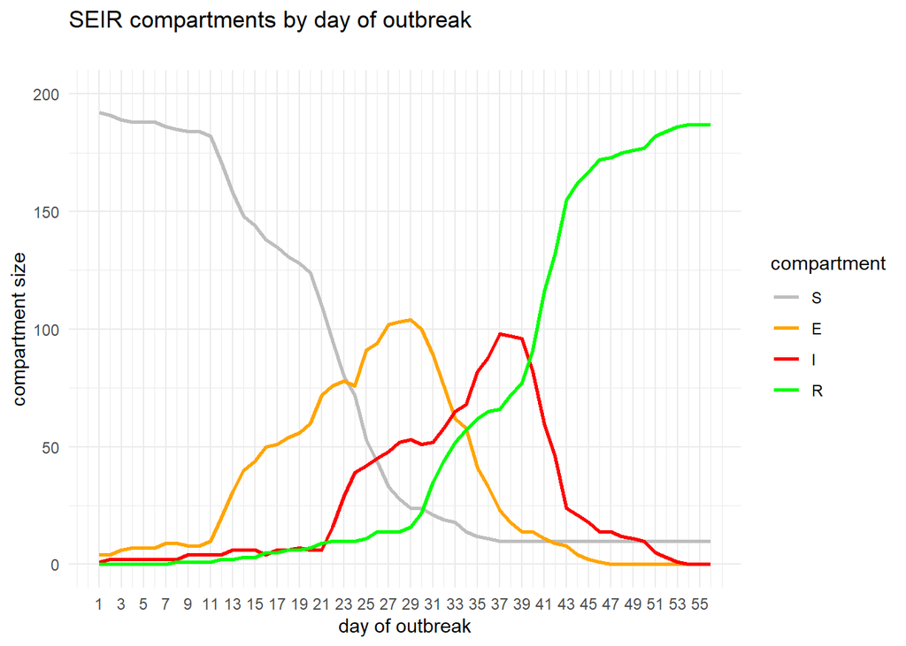

```r
df_dates <- df_dates %>% filter(day > 0)
df_SEIR <- fn_calc_SEIR(df_measles, df_dates, 197)

df_SEIR <- df_SEIR %>%
    # first derivative of the rate of change of E
    mutate(first_derivative = (E - lag(E)) / (day - lag(day))) %>%
    mutate(first_derivative = round(first_derivative, 2)) %>%
    # second derivative of the rate of change of I
    mutate(second_derivative = first_derivative - lag(first_derivative)) %>%
    mutate(second_derivative = round(second_derivative, 2)) %>%
    identity()

p_SEIR <- fn_plot_SEIR(df_SEIR, ' ') +
    labs(title = 'SEIR compartments by day of outbreak')
p_SEIR
```

# Step 4 - Exposure and Infection prevalance.

Plot the size of the I compartment over time, overlay assumed E compartment.  
Illustrate the associated acceleration of the transmission rate (second derivative of E).

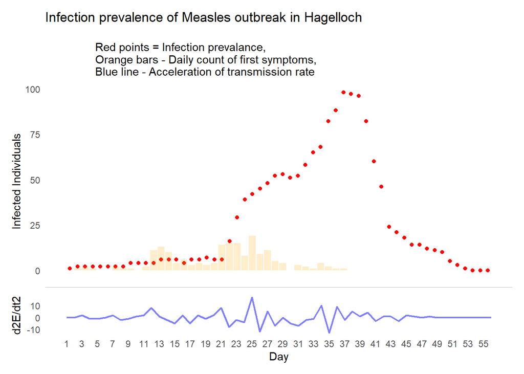

```r
df_cases <- df_dates %>%
    left_join(
        df_measles %>%
        mutate(tI = round(tPRO) - 10) %>%
        count(tI) %>%
        setNames(c('day', 'exposure')) %>%
        identity(), by='day'
    ) %>%
    left_join(
        df_SEIR %>%
        select(day, I, first_derivative, second_derivative) %>%
        # useful dummy endpoint
        identity(), by='day'
    ) %>%
    replace(is.na(.), 0) %>%
    identity()

p_cases <- ggplot(df_cases, aes(day, I)) +
            geom_point(color = 'red') +
            geom_col(aes(day, exposure), alpha = 0.2, fill = 'orange', show.legend = FALSE) +
            theme_minimal() +
            theme(
                axis.text.x = element_blank(),
                axis.title.x = element_blank(),
                panel.grid = element_blank()
            ) +
            labs(title = "Infection prevalence of Measles outbreak in Hagelloch",
                 subtitle = "
                Red points = Infection prevalance,
                Orange bars - Daily count of first symptoms,
                Blue line - Acceleration of transmission rate",
                 y = 'Infected Individuals',
                 x = NULL)

divider <- ggplot() +
  geom_hline(yintercept = 0, linewidth = 0.3, colour = 'grey') +
  theme_void()

p_acceleration <- ggplot(df_cases, aes(day, second_derivative)) +
                geom_line(color = "blue", linewidth = 0.8, alpha = 0.5) +
                theme_minimal() +
                labs(y = "d2E/dt2", x = "Day") +
                scale_x_continuous(breaks = seq(1, nrow(df_cases), 2)) +
                theme(panel.grid = element_blank())

(p_cases / divider / p_acceleration) + plot_layout(heights = c(4, 0.1, 0.8))
```

# Step 5 - SEIR model of outbreak

### 5.1 What we know from the literature

From published literature the reported number of inhabitants in the village at the time of the outbreak was 577, with 197 children under the age of 15.

There were 12 children who didn’t get measles, reportedly because  
- 1 child had previous measles (immune)  
- 3 siblings were kept isolated  
- 7 infants (<6 months) — likely protected by maternal antibodies  
- 1 child (~2 years old) — unclear reason

There’s a discrepancy in numbers here, with 188 infections in the dataset, and 12 reported non-infections the total children should be 200 rather than 197. We’ll remove the 7 infants and 1 immune from the Susceptible compartment and use 192 for the value of N in a deterministic model. Although there are some Deaths in the population, as Measles confers lasting immunity we’ll assume those individuals are part of the Recovered compartment.

From the provided dataset we know 109 individuals recovered from the first wave, and 78 from the second.

### 5.2 Compartment equations

$\Delta S = -\frac{\beta S I}{N}$  
$\Delta E = \frac{\beta S I}{N} - \alpha E$  
$\Delta I = \alpha E - \gamma I$  
$\Delta R = \gamma I$

Where -  
$\beta$ = transmission rate, may be different for Wave 1 and Wave 2 depending on social contacts  
$\alpha$ = incubation rate (1/number of days exposed)  
$\gamma$ = removal rate (1/number of days infectious)

### 5.3 Compartment parameters

$\alpha$ = incubation : we know who infected who and their symptom onset date, we can calculate SI (serial interval)  
$\gamma$ = removal : we have symptom start day and recovery day we can estimate days infected from data

```r
# look at some summary stats for (assumed) Wave1 and Wave2
df_stats <- df_measles %>%
    mutate(wave = case_when(GE == 1 ~ 'Wave 1', GE == 2 ~ 'Wave 2')) %>%
    group_by(wave) %>%
    summarise(total = n(),
              mean_SI = round(mean(SI, na.rm = TRUE), 1),
              mean_Infected_days = round(mean(days_infected), 1),
              infected_on_day1 = sum(tPRO <= 1),
              infected_on_day9 = sum(tPRO <= 9),
              mean_age = round(mean(AGE), 1),
              pcent_preschool = sum(CL == 'preschool', na.rm = TRUE) / n() * 100,
              pcent_class1 = sum(CL == '1st class', na.rm = TRUE) / n() * 100,
              pcent_class2 = sum(CL == '2nd class', na.rm = TRUE) / n() * 100
              ) %>%
    ungroup() %>%
    pivot_longer(
        cols = -wave,
        names_to = "description",
        values_to = "value"
    ) %>%
    mutate(description = recode(description, 'total' = 'Total sample')) %>%
    pivot_wider(
        names_from = wave,
        values_from = value
    ) %>%
    setNames(c('description', 'wave_1', 'wave_2')) %>%
    identity()

df_stats %>% gt() %>%
    tab_header(title = 'Population Statistics for Wave 1 and 2 of Hagelloch Measles Outbreak',
               subtitle = 'Infected Individuals only') %>%
    fmt_number(columns = c(wave_1, wave_2), decimals = 1) %>%
    opt_vertical_padding(scale = 0)
```

Population Statistics for Wave 1 and 2 of Hagelloch Measles Outbreak

Infected Individuals only

| description | wave_1 | wave_2 |
| --- | --- | --- |
| Total sample | 109.0 | 78.0 |
| mean_SI | 10.1 | 10.7 |
| mean_Infected_days | 7.4 | 6.4 |
| infected_on_day1 | 1.0 | 0.0 |
| infected_on_day9 | 4.0 | 0.0 |
| mean_age | 8.0 | 5.7 |
| pcent_preschool | 33.0 | 67.9 |
| pcent_class1 | 26.6 | 1.3 |
| pcent_class2 | 40.4 | 30.8 |

**N** : from the literature as 192 Susceptible individuals  
**E** : on day 9 there are 4 infected individuals, assume Exposed but not yet symptomatic on day 1 (ie Latent)  
**I** : on day 1 of the outbreak there is 1 Infected individual  
**R** : zero at the start of the outbreak

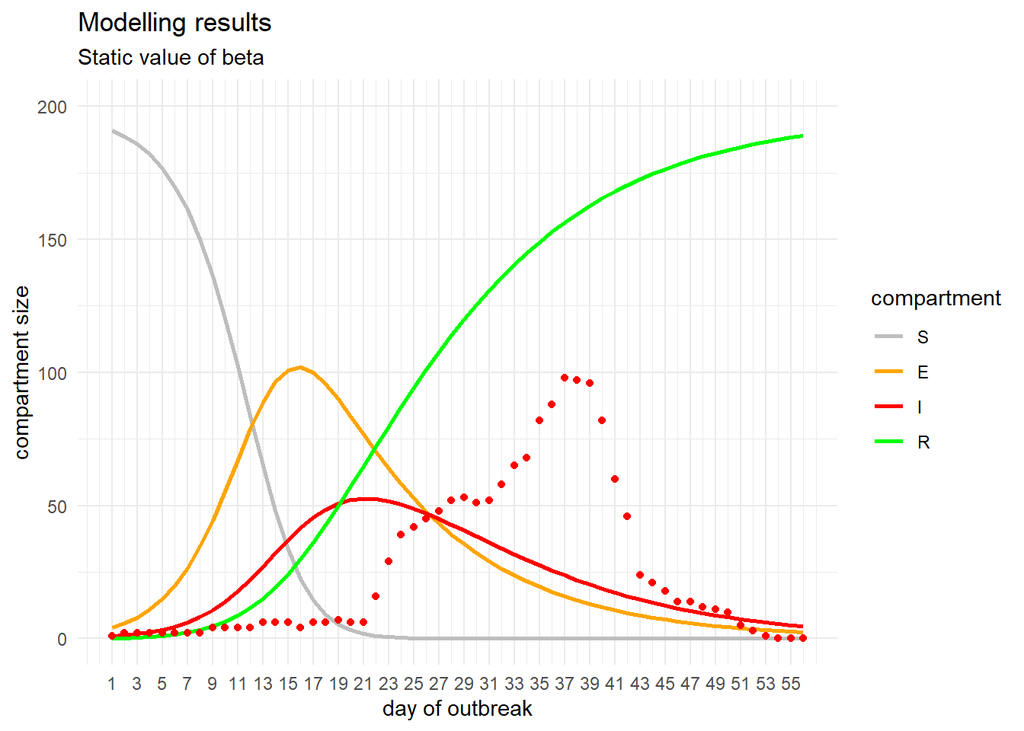

```r
# model from day 1 of the outbreak
df_cases_model <- df_cases %>% filter(day > 0)

# get timestep of days as vector
model_timesteps <- df_cases_model %>% pull(day) %>% as.integer()

# Initial values
N <- 192 # we are told this in the literature
I0 <- df_cases %>% slice(1) %>% pull(I) # Infected on day 1
E0 <- 4 # make an assumption about the number Exposed on day 1

# parameters
params <- c(beta = 2, alpha = 1/10, gamma = 1/7)
inits <- c(S = N-I0, E = E0, I = I0, R = 0)

# Use ode() to solve with standard model
model1 <- ode(y = inits,
            times = model_timesteps,
            func = model_SEIR,
            parms = params)
df_model1 <- as_tibble(model1)

df_plot <- df_cases_model %>% select(day, I_observed = I) %>%
    left_join(df_model1 %>%
              mutate(time = as.double(time)) %>%
              select(day = time, S, E, I, R) , by = 'day') %>%
    identity()

R0 <- params[1] / params[3]
p <- fn_plot_SEIR(df_plot, 'Static value of beta') +
    labs(title = "Modelling results")
p
```

An SEIR model assumes a constant contact rate in the population. Applying this model to the dataset quickly exhausts the S compartment, and does not result in an accurate representation of the outbreak.

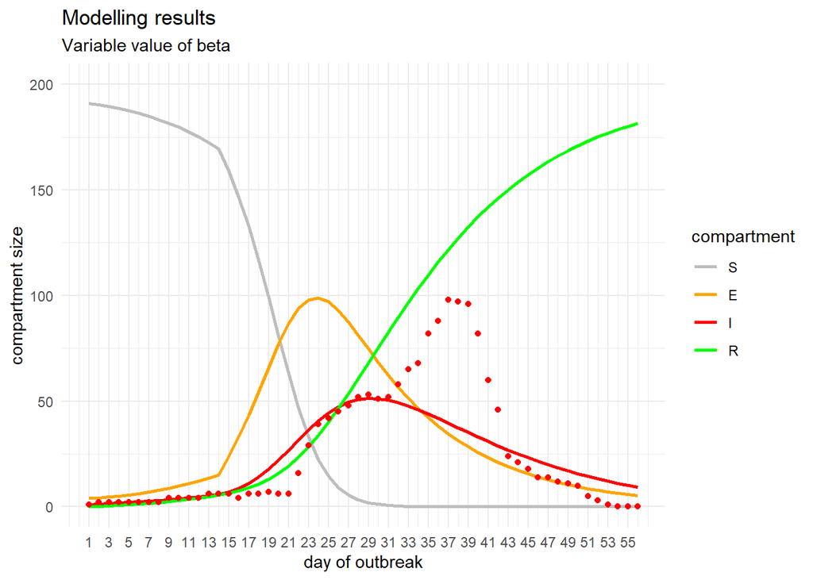

```r
# Use ode() to solve with model where beta varies
model2 <- ode(y = inits,
            times = model_timesteps,
            func = model_SEIR_variable,
            parms = params)
df_model2 <- as_tibble(model2)

df_plot <- df_cases_model %>% select(day, I_observed = I) %>%
    left_join(df_model2 %>%
              mutate(time = as.double(time)) %>%
              select(day = time, S, E, I, R) , by = 'day') %>%
    identity()

R0 <- params[1] / params[3]
p <- fn_plot_SEIR(df_plot, 'Variable value of beta') +
    labs(title = "Modelling results")
p
```

### SEIR datasets for each wave

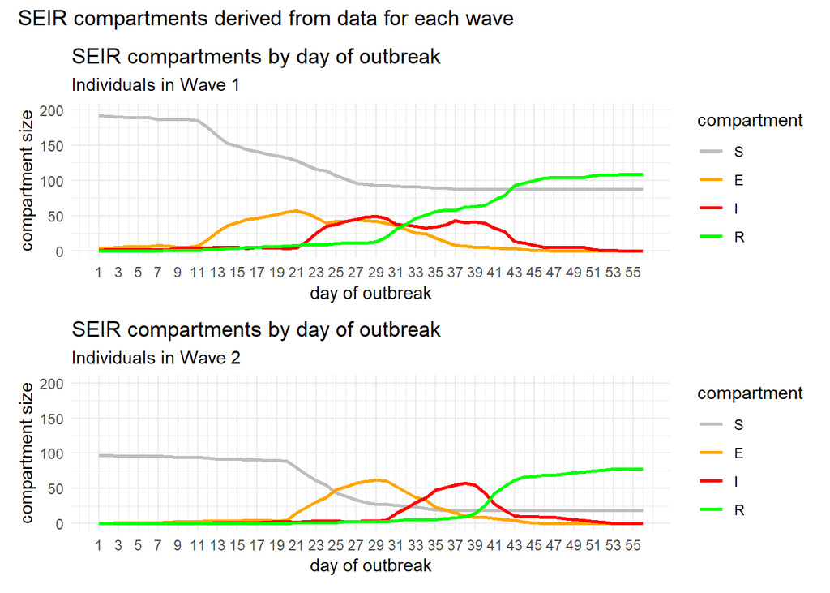

```r
df_SEIR1 <- fn_calc_SEIR((df_measles %>% filter(GE == 1)), df_dates, 197)
df_SEIR2 <- fn_calc_SEIR((df_measles %>% filter(GE == 2)), df_dates, 97)

p_SEIR1 <- fn_plot_SEIR(df_SEIR1, 'Individuals in Wave 1')
p_SEIR2 <- fn_plot_SEIR(df_SEIR2, 'Individuals in Wave 2')
p_SEIR1 / p_SEIR2 + plot_annotation(title='SEIR compartments derived from data for each wave')
```

# Step 6 - Estimate R with EpiEstim package

We can use the EpiEstim package to estimate R for the Hagelloch outbreak. Given gamma is constant, any change in R must reflect change in beta.

```r
SI_mean <- round(mean(df_measles$SI, na.rm = TRUE))
SI_std <- round(sd(df_measles$SI, na.rm = TRUE))

# Estimate R using parametric serial interval
res <- estimate_R(incid = df_cases %>% select(dates = date, I),
                  method = "parametric_si",
                  config = make_config(list(
                    mean_si = 10,
                    std_si = 2
                  )))
```

```
## Default config will estimate R on weekly sliding windows.
##     To change this change the t_start and t_end arguments.
```

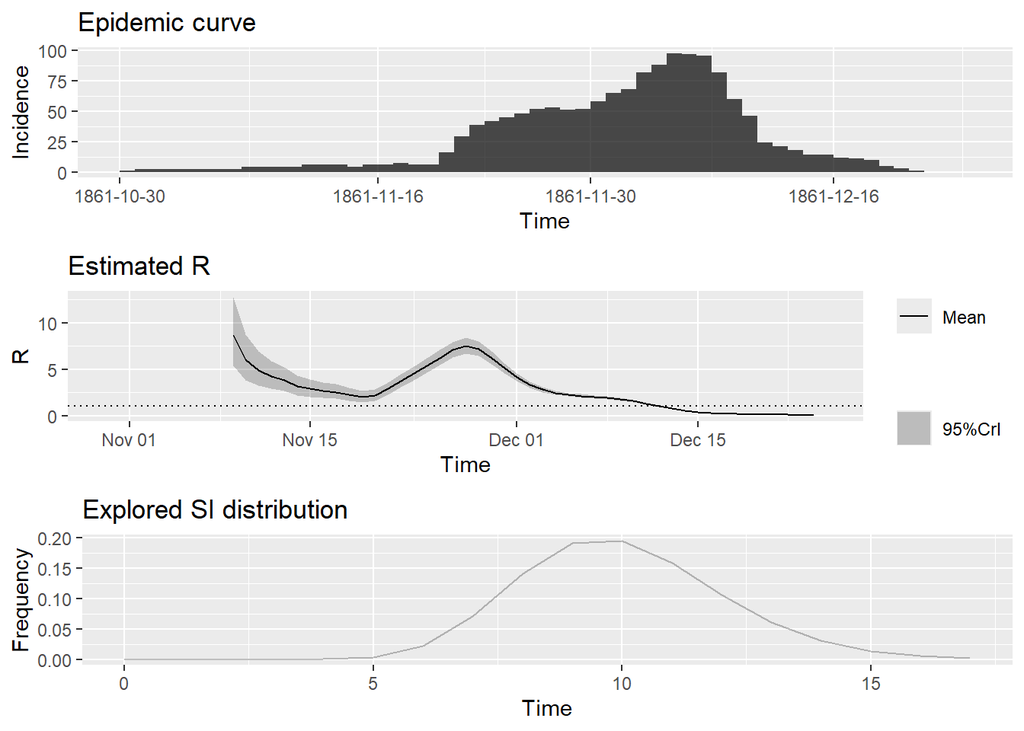

```r
# Plot the results
plot(res)
```

# Step 7 - Contact Tracing Network

```r
df_measles %>%
    count(IFTO) %>%
    arrange(desc(n)) %>%
    left_join(df_measles %>% select(IFTO = PN, PRO, tPRO), by='IFTO') %>%
    mutate(tPRO = round(tPRO)) %>%
    setNames(c('Source Individual','Number Infected','Date First Symptoms','Day First Symptoms')) %>%
    slice(1:6) %>%
    gt() %>%
    tab_header(title = 'Contact Network',
               subtitle = 'Highest secondary infections') %>%
    opt_vertical_padding(scale = 0)
```

Contact Network

Highest secondary infections

| Source Individual | Number Infected | Date First Symptoms | Day First Symptoms |
| --- | --- | --- | --- |
| 45 | 30 | 1861-11-11 | 13 |
| 181 | 8 | 1861-11-13 | 14 |
| 7 | 7 | 1861-11-24 | 25 |
| 17 | 7 | 1861-11-20 | 22 |
| 180 | 7 | 1861-11-17 | 18 |
| 153 | 6 | 1861-11-24 | 26 |

```r
df_measles_orig %>%
    filter(PN == 45)
```

```
##   PN     NAME FN HN AGE  SEX        PRO        ERU        CL DEAD IFTO SI
## 1 45 Goehring 48 51   7 male 1861-11-11 1861-11-13 1st class <NA>  184 12
##                 C PR CA NI GE TD TM x.loc y.loc     tPRO     tERU tDEAD
## 1 no complicatons  2  3  1  1 NA NA    75    55 12.84756 14.45254    NA
##         tR       tI
## 1 17.45254 11.84756
```

A few Individuals infect many others, so the rate of infection is not constant.

# Step 8 - Measles in the UK 1940-2025

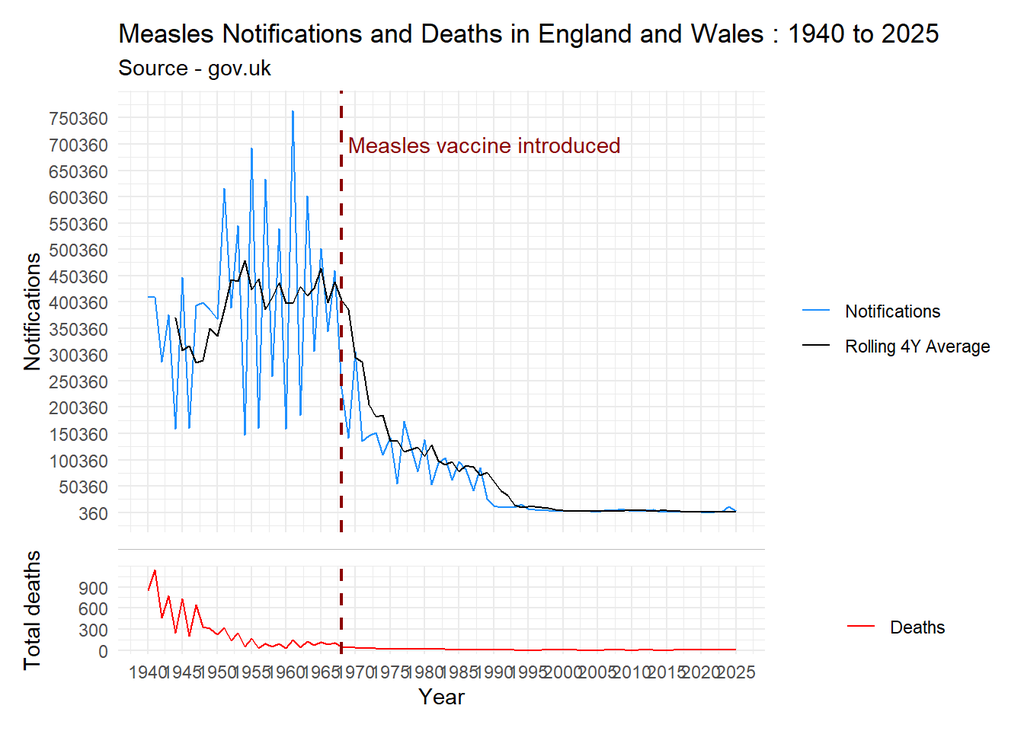

```r
# Chart Notifications and Deaths over time
xticks <- seq(min(df_uk$Year), max(df_uk$Year), by = 5)
line_colours <- c("Notifications" = "dodgerblue", "Deaths" = "red", "Rolling 4Y Average" = "black")

yticks <- seq(min(df_uk$Notifications), max(df_uk$Notifications), by = 50000)
p1 <- df_uk %>%
    ggplot(aes(x = Year)) +
    geom_line(aes(y = Notifications, colour = "Notifications")) +
    geom_line(aes(y = rolling4, colour = 'Rolling 4Y Average')) +
    scale_colour_manual(name = '', values = line_colours) +
    scale_x_continuous(breaks = xticks) +
    scale_y_continuous(breaks = yticks) +
    theme_minimal() +
    theme(
        axis.text.x = element_blank(),
        axis.title.x = element_blank()
    ) +
    geom_vline(xintercept = 1968, linewidth = 0.8, linetype = 2, colour = 'red4') +
    labs(title = "Measles Notifications and Deaths in England and Wales : 1940 to 2025",
         subtitle = 'Source - gov.uk') +
    annotate("text", x = 1969, y = 700000, hjust = 0,
             label = "Measles vaccine introduced", colour = 'red4')

divider <- ggplot() +
  geom_hline(yintercept = 0, linewidth = 0.3, colour = 'grey') +
  theme_void()

yticks <- seq(min(df_uk$`Total deaths`), max(df_uk$`Total deaths`), by = 300)
p2 <- df_uk %>%
    ggplot(aes(x = Year)) +
    geom_line(aes(y = `Total deaths`, colour = "Deaths")) +
    scale_colour_manual(name = '', values = line_colours) +
    scale_x_continuous(breaks = xticks) +
    scale_y_continuous(breaks = yticks) +
    theme_minimal() +
    geom_vline(xintercept = 1968, linewidth = 0.8, linetype = 2, colour = 'red4')

p1 / divider / p2 + plot_layout(heights = c(4, 0.1, 0.8))
```

We can see how the introduction of the Measles vaccine in 1968 dramatically affected the prevalence of Measles.

# Step 9 - Animate the geographical spread of the Hagelloch outbreak

```r
# location. As a family shares the same location, add some noise so they show as clusters
jitter <- 4
df_animate_location <- df_measles %>%
    # each x,y location has multiple people, create small clusters
    select(PN, x.loc, y.loc) %>%
    mutate(x.locjit = x.loc + rnorm(n(), 0, jitter)) %>%
    mutate(y.locjit = y.loc + rnorm(n(), 0, jitter)) %>%
    identity()

# days when an individual moves compartments
df_compartment_days <- df_measles %>%
    mutate(day_I = round(tPRO)) %>%
    mutate(day_R = round(tR) + 1) %>%
    mutate(day_E = day_I - 10) %>%
    select(PN, day_E, day_I, day_R )

# make a df of compartment each day for each individual
df_animate <-
    cross_join(df_dates, df_compartment_days) %>%
    arrange(PN) %>%
    mutate(compartment = case_when(day < day_E ~ 'S',
                                day < day_I ~ 'E',
                                day < day_R ~ 'I',
                                day >= day_R ~ 'R')) %>%
    # make compartment a factor to get the order correct
    mutate(compartment = factor(compartment, levels=c('S','E','I','R'))) %>%
    group_by(PN, compartment) %>%
        mutate(days_in_compartment = row_number()) %>%
    ungroup() %>%
    mutate(days_in_compartment = case_when(compartment == 'S' ~ 2,
                                           compartment == 'R' ~ 2,
                                           T ~ days_in_compartment)) %>%
    left_join(df_animate_location, by = 'PN') %>%
    identity()
```

[output not shown]

[output cut: 67 more lines]

[output not shown]

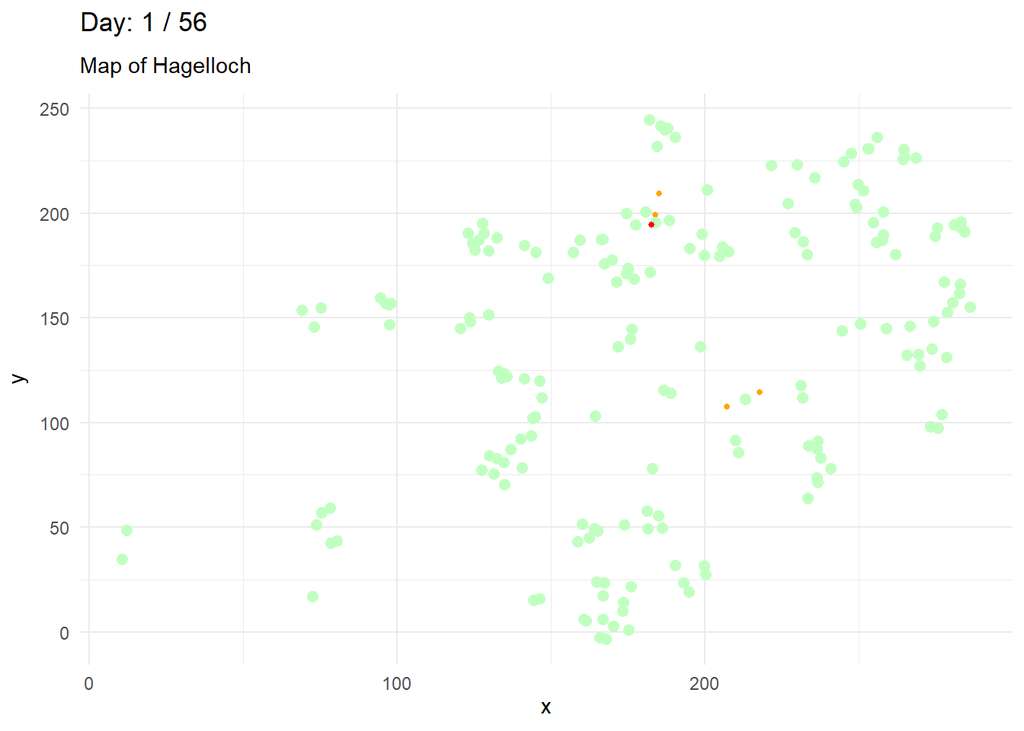

```r
count_days <- nrow(df_dates)
compartment_colour <- c(S = "darkseagreen1", E = "orange", I = "red", R = "grey")

# test how each slide looks
# for (i in 11:14) {
#     p <- df_animate %>%
#         filter(day == i) %>%
#         ggplot(aes(x.locjit, y.locjit, colour = compartment, group=day)) +
#         geom_point(aes(size = days_in_compartment)) +
#         scale_colour_manual(values = compartment_colour) +
#         theme_minimal() +
#         labs(title = paste('Slide ', i),
#         subtitle = 'Map of Hagelloch',
#         x = 'x',
#         y = 'y') +
#         theme(legend.position = 'none')
#     print(p)
# }

p <- df_animate %>%
    ggplot(aes(x.locjit, y.locjit, colour = compartment, group=day)) +
    geom_point(aes(size = days_in_compartment)) +
    scale_colour_manual(values = compartment_colour) +
    labs(title = 'Day: {frame_time} / {count_days}',
        subtitle = 'Map of Hagelloch',
        x = 'x',
        y = 'y') +
    theme_minimal() +
    theme(legend.position = 'none') +
    transition_time(day) +
    ease_aes('linear')

gganimate::animate(p, fps = 10, nframes = count_days * 10, renderer = gifski_renderer())
```